# Patient Outcome Analysis: Heart Disease Factors

Jacob Doh

## Executive Summary

```r
# Load necessary libraries
library(tidyverse)
```

```r
library(ggplot2)

# Contains professional "Heart" data set
data(heart, package = "survival")

# Data cleaning
heart_clean <- heart %>%
  mutate(Age = round(age + 48), # correcting to actual age
    Status = factor(event, levels = c(0, 1), labels = c("Stable", "Outcome")), # labeling clinical outcomes
    Monitoring_Days = as.integer(stop - start),  # calculating total observation period
    Transplant = factor(transplant, levels = c(0, 1), labels = c("No", "Yes"))) %>% # labeling transplant status
  select(Age, Status, Monitoring_Days, Transplant)
heart_clean
```

```
##     Age  Status Monitoring_Days Transplant
## 1    31 Outcome              50         No
## 2    52 Outcome               6         No
## 3    54  Stable               1         No
## 4    54 Outcome              15        Yes
## 5    40  Stable              36         No
## 6    40 Outcome               3        Yes
## 7    21 Outcome              18         No
## 8    55 Outcome               3         No
## 9    51  Stable              51         No
## 10   51 Outcome             624        Yes
## 11   45 Outcome              40         No
## 12   47 Outcome              85         No
## 13   43  Stable              12         No
## 14   43 Outcome              46        Yes
```

[output cut: 158 more lines]

```r
# Verify cleaned data and count
heart_count <- nrow(heart_clean) # counting 172
heart_count
```

```
## [1] 172
```

## Exploratory Data Analysis

### Age Distribution of Heart Patients

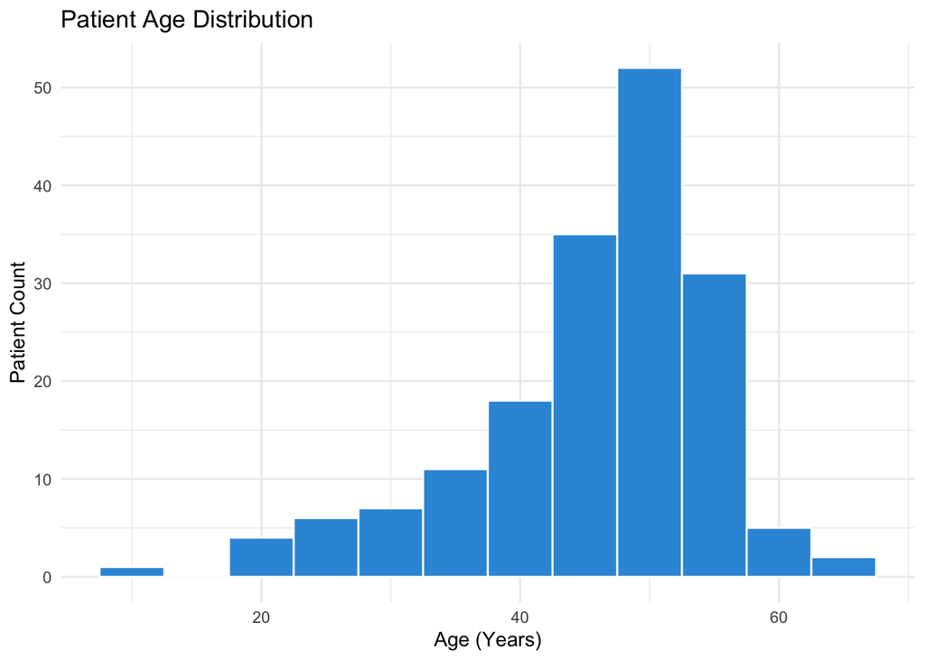

```r
# creating plot
ggplot(heart_clean, aes(x = Age)) +
  geom_histogram(binwidth = 5, fill = "#3498db", color = "white") +
  labs(title = "Patient Age Distribution", x = "Age (Years)", y = "Patient Count") +
  theme_minimal()
```

**Insights:**

- Main Observation: we observed that the heart transplant wait-list is not evenly distributed across all ages. The data shows a clear “bell shape” that peaks between the ages of 45 and 55.
- Analysis: This suggests that middle-aged patients are the primary group requiring heart transplants in this data set. we found an interesting thing that there are very few patients under 30 or over 65, which might mean that heart issues in this group typically arise during middle age.
- Application: In health care systems, this information could be used to prioritize screening resources for patients entering their 40s.

### Monitoring Duration vs Clinical Status

We analyze if there’s a pattern between how long a patient was monitored and their final clinical status.

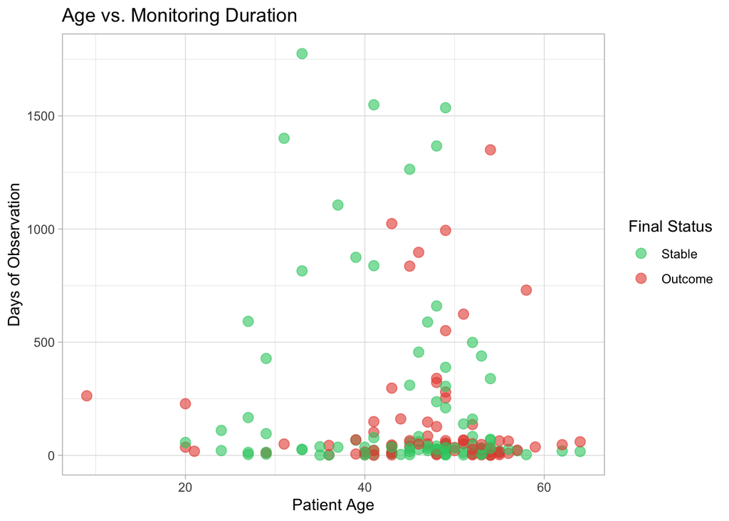

```r
# creating plot
ggplot(heart_clean, aes(x = Age, y = Monitoring_Days, color = Status)) +
  geom_point(size = 3, alpha = 0.6) +
  scale_color_manual(values = c("#2ecc71", "#e74c3c")) +
  labs(title = "Age vs. Monitoring Duration",
       x = "Patient Age", y = "Days of Observation",
       color = "Final Status") +
  theme_light()
```

**Insights:**

- Main Observation: Looking at the scatter plot, we noticed that a lot of “Outcomes” (red dots) happen very early—within the first 200 days of monitoring.
- Analysis: It seems the first few months are the most critical for any age group. Age itself didn’t seem to guarantee a longer or shorter monitoring period, but staying stable in the beginning is the key to long-term survival.
- Application: This data tells me that hospital systems should trigger “high-alert” notifications for new patients during their first 6 months on the wait-list to improve overall outcomes.